# Maze Game Data Analysis

##### Session Learning

This improvement is more associated to a “warming up” effect. Temporary improvements that represents how players evolve from starting to play to having accumulated some games on a row.

Similarly, a small decrease can be detected in the response time, although in most cases it is limited to the earliest trials of the session, probably showing that participants needs a few trials or blocks to get into the mindset to solve the mazes. However, this effect is less prominent that overall learning, and additional data from more players could help determine the consistency of this effect.

In terms of accuracy, we find different profiles between participants. Considering the lack of more data, the patterns are inconclusive.

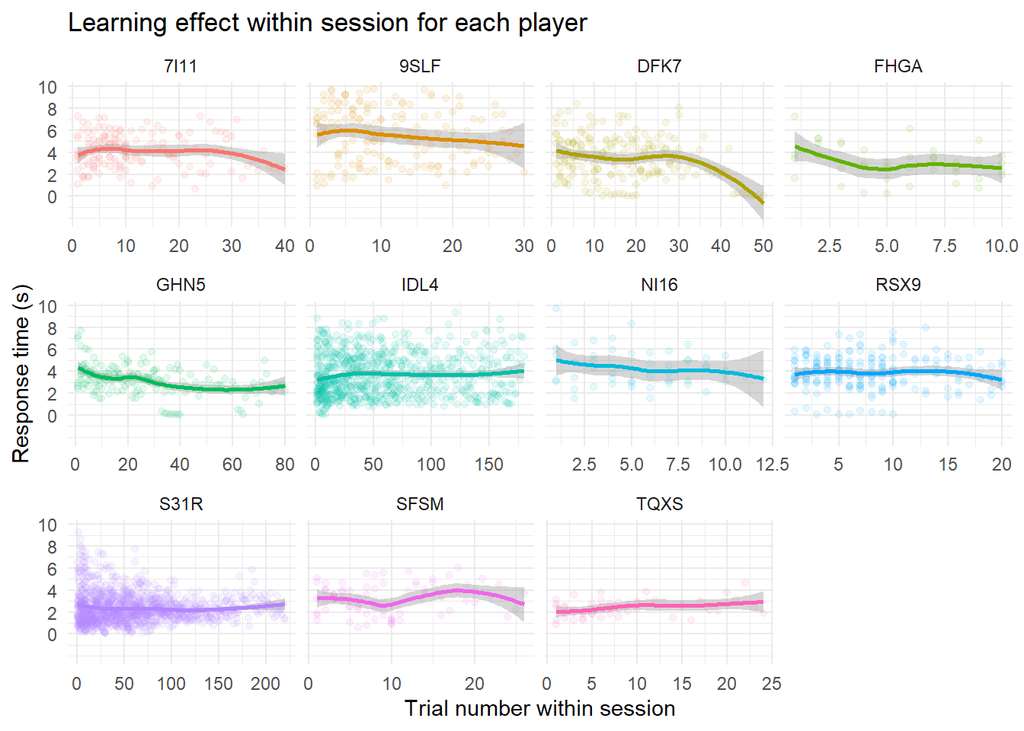

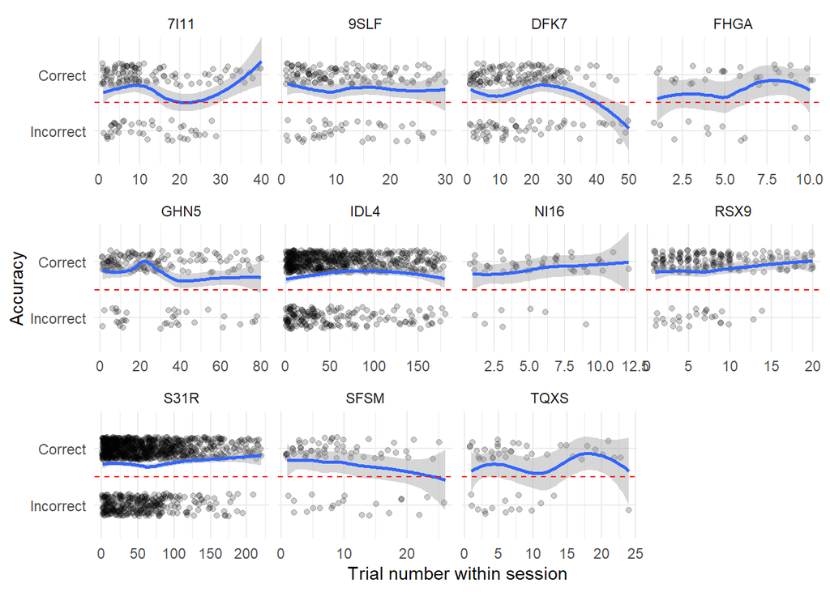

##### Block Learning

Similarly to session learning, block learning is even more limited. Including the trials within the same block we evaluate how the pressure of the scores being accumulated towards the end of the block to be averaged into the final score takes effect in players’ performance.

There does not seem to be any consistent pattern between the trial number and the response time or the accuracy, meaning that the time participants need to give an answer is not necessarily different through the course of a block nor are there specific trials where accuracy is improved.

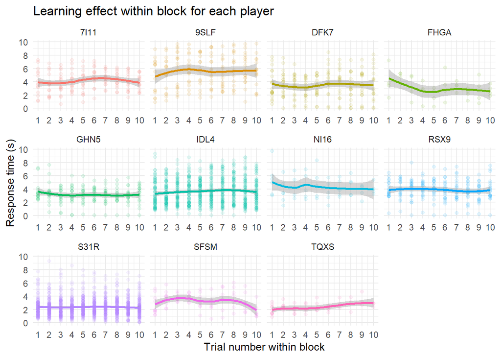

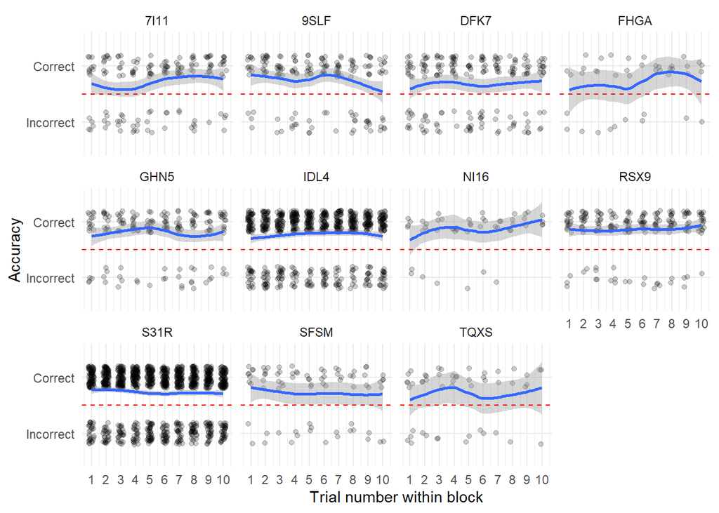

## Future Analysis

- **Post-error behavior**
  - Effect of mistakes on subsequent RT and accuracy.
  - Serial dependencies.
- **More difficulty metrics**
  - Similarity between current and previous mazes.
  - Path width and center
  - Symmetry of the maze and/or the path
- **Identifying troublesome cells**
  - Detect areas that when being part of the path reduce accuracy of some players (as individual differencies).